# Assignment 2 Report

Mrugakshi Chidrawar

1/1/2022

**Please read this brief introduction to R Markdown, and complete the second half using your `main.R` functions.**

# R Markdown

R Markdown, `.Rmd` files, are a type of markdown files that can execute R code in an R environment. Markdown is an open source language used for easily creating documents such as web pages and PDFs. Markdown and R Markdown can be used to procedurally generate documents and reports, which have a wide number of use-cases across bioinformatics. Not only can you save time by creating code to automatically draft documents, you can also include detailed instructions and information alongside your code.

## knitr

`knitr` is simply the package R uses to convert the R Markdown into the appropriate output (HTML, PDF, or Word). While there is a deep level of customization available, most users can comfortably create beautiful documents with the default parameters. In order to compile your markdown, in RStudio you can select the `Knit` button below the open file button.

## Markdown Basics

The raw markdown, which you may or may not be looking at, is styled very basically. The largest titles start with one octothorpe `#`. The more `#`’s added, the smaller a title or header becomes. These headings can be used to complete a table of contents, in some situations (like the class website).

# Biggest

## 2nd Biggest

### so on

#### and so forth

##### until you have

###### six octothorpes

then nothing happens.

Importantly, two spaces () can be included after a line of text to start a new line.

Markdown can be styled a few different ways:  
`_italics_` -> *italics*  
`**bold**` -> **bold**  
`` `monospace` `` -> `monospace`, good for code

A good cheat sheet is the [Markdown Guide Cheat Sheet](https://www.markdownguide.org/cheat-sheet)

## R Code in Markdown

The really vital part of R Markdown is the inclusion of code snippets you can place into the document, which will run and print out to users. In this snippet I create a function that says hello and that text is printed inside the document.

```r
say_hi <- function() {
  return("Hello world.")
}
print(say_hi())
```

```
## [1] "Hello world."
```

The syntax of the **snippet* is simple, with three back ticks `` ``` `` indicating the start and end of the snippet, and a lower case `r` in curly braces `{}` to indicate what language is used: `{r}` indicates R, `{python}` indicates Python. R Markdown does not support every language, but there are use cases where one document running both R and Python code can prove extremely useful and concise. There is also a button in RStudio to insert a snippet, it is a small green `+C` in the top right of the editor.

```python
import datetime
print(f'Wishing you a wonderful hello from Python at {datetime.datetime.now()}')
```

```
## Wishing you a wonderful hello from Python at 2022-02-13 20:16:35.184453
```

I can also test my code in RStudio without having to knit the entire document by pressing the green “Play” arrow on the snippet I am interested in.

Finally, R Markdown scripts can `source()` other `.R` scripts and use them in their execution environment. This mean I can define a function in my `main.R` script and use it in my R Markdown snippets. Note that the converse is true, using `knitr::purl()`, and the code established in an R Markdown can be sourced, and *tested*, using an normal `.R` script.

Also note that the environment is carried from one snippet to another, so if I define a function or load a file in one snippet I can use those objects in later snippets.

```r
message <- 'The last example...for now.'
```

```r
print(paste(message, 'But there\'s always room for more.'))
```

```
## [1] "The last example...for now. But there's always room for more."
```

# Assignment

Using what you know from this document and the `main.R` script, use the functions from `main.R` to draw a box plot of expression levels. Use this R Markdown document to describe your code as you are using it in this document, as done above. Take time to enhance your ggplot function from the `main.R` script with high quality visual aesthetics. Do not use default ggplot colors.

Our first step is to source our `main.R` script to load our completed functions, and then load the data from the sample csv. This filepath should work if you are on the SCC, but a copy is also located in this repository’s `data/` directory. Some functions in R can manage zipped data, but you may need to unzip (`unzip example_data.zip` on command line) the file before loading it into R.

```r
# use source to load your functions from main.R into this document.
source("main.R")
expr <- load_expression("data/example_intensity_data.csv")
head(expr)
```

```
## # A tibble: 6 × 36
##   probeids GSM972389 GSM972390 GSM972396 GSM972401 GSM972409 GSM972412 GSM972413
##   <chr>        <dbl>     <dbl>     <dbl>     <dbl>     <dbl>     <dbl>     <dbl>
## 1 1007_s_…      9.54     10.2       9.72      9.68      9.35      9.89      9.70
## 2 1053_at       7.62      7.92      7.17      7.24      8.20      6.87      6.62
## 3 117_at        5.50      5.56      5.06      7.44      5.19      5.72      5.87
## 4 121_at        7.27      7.96      7.42      7.34      7.49      7.76      7.44
## 5 1255_g_…      2.79      3.10      2.78      2.91      3.02      2.73      2.78
## 6 1294_at       7.51      7.28      7.00      7.18      7.38      6.98      6.90
## # … with 28 more variables: GSM972422 <dbl>, GSM972429 <dbl>, GSM972433 <dbl>,
## #   GSM972438 <dbl>, GSM972440 <dbl>, GSM972443 <dbl>, GSM972444 <dbl>,
## #   GSM972446 <dbl>, GSM972453 <dbl>, GSM972457 <dbl>, GSM972459 <dbl>,
## #   GSM972463 <dbl>, GSM972467 <dbl>, GSM972472 <dbl>, GSM972473 <dbl>,
## #   GSM972475 <dbl>, GSM972476 <dbl>, GSM972477 <dbl>, GSM972479 <dbl>,
## #   GSM972480 <dbl>, GSM972487 <dbl>, GSM972488 <dbl>, GSM972489 <dbl>,
## #   GSM972496 <dbl>, GSM972502 <dbl>, GSM972510 <dbl>, GSM972512 <dbl>, …
```

Next, we apply the `filter_15()` function to eliminate some rows from out data. The rows remaining will have at least 15% of the expressions values above log<sub>2</sub>(15). We pass this smaller set of rows to `affy_to_hgnc()` which will find the HGNC gene ID based on the the affymetrix probe ID; we store those results in a separate data frame.

```r
filter_15(expr) %>%
affy_to_hgnc() -> sample_names
head(sample_names)
```

```
## # A tibble: 6 × 2
##   affy_hg_u133_plus_2 hgnc_symbol
##   <chr>               <chr>
## 1 1553551_s_at        MT-ND1
## 2 1553551_s_at        MT-TI
## 3 1553551_s_at        MT-TM
## 4 1553551_s_at        MT-ND2
## 5 1553551_s_at        MT-TW
## 6 1553570_x_at        MT-CO1
```

```r
goodGenes <- c("PKD1", "NOS3", "AGTR1", "COL4A5", "ECE1", "MEN1", "OLR1", "F7")
badGenes <- c("TP53", "EGFR", "BRAF", "KRAS", "PIK3CA", "ERBB2", "MAPK1", "NRAS")
plot_tibble <- reduce_data(expr_tibble = expr,
                           names_ids = sample_names,
                           goodGenes,
                           badGenes)
head(plot_tibble)
```

```
## # A tibble: 6 × 38
##   probeids     hgnc_symbol gene_set GSM972389 GSM972390 GSM972396 GSM972401
##   <chr>        <chr>       <chr>        <dbl>     <dbl>     <dbl>     <dbl>
## 1 1552263_at   MAPK1       bad           6.01      5.93      5.22      6.25
## 2 1552264_a_at MAPK1       bad           7.42      7.73      6.86      7.83
## 3 1559204_x_at KRAS        bad           5.61      5.80      6.00      6.00
## 4 1565483_at   EGFR        bad           5.35      4.74      5.48      4.37
## 5 1565484_x_at EGFR        bad           4.96      4.64      4.91      4.16
## 6 201746_at    TP53        bad           7.65      8.30      7.32      7.70
## # … with 31 more variables: GSM972409 <dbl>, GSM972412 <dbl>, GSM972413 <dbl>,
## #   GSM972422 <dbl>, GSM972429 <dbl>, GSM972433 <dbl>, GSM972438 <dbl>,
## #   GSM972440 <dbl>, GSM972443 <dbl>, GSM972444 <dbl>, GSM972446 <dbl>,
## #   GSM972453 <dbl>, GSM972457 <dbl>, GSM972459 <dbl>, GSM972463 <dbl>,
## #   GSM972467 <dbl>, GSM972472 <dbl>, GSM972473 <dbl>, GSM972475 <dbl>,
## #   GSM972476 <dbl>, GSM972477 <dbl>, GSM972479 <dbl>, GSM972480 <dbl>,
## #   GSM972487 <dbl>, GSM972488 <dbl>, GSM972489 <dbl>, GSM972496 <dbl>, …
```

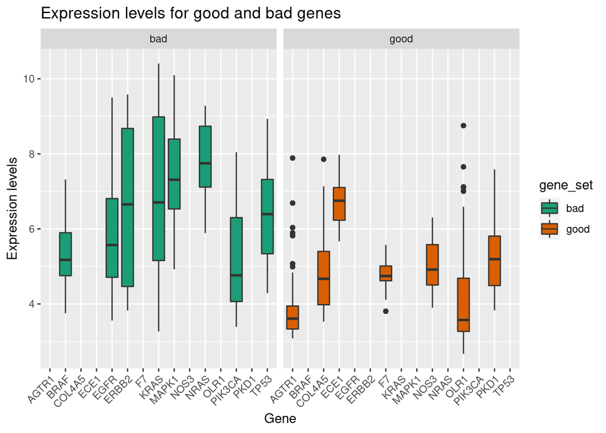

```r
plot_ggplot(plot_tibble)
```